# Statistical Inference Course Project- Part II

Zohar Peleg

Thursday, August 14, 2014

This is the second part of the statistical inference course project, which contains an analysis of the ToothGrowth data in the R datasets package. This report does not show the full R code. The complete reproduceable code can be found at my github account at https://github.com/zoharpeleg/Statistical-Inference-Course-Project

**Description of the data**

The ToothGrowth data explores the effect of Vitamin C on Tooth Growth in Guinea Pigs: The length of teeth in each of 10 guinea pigs at each of three dose levels of Vitamin C: 0.5, 1, and 2 mg and with each of two delivery methods: orange juice (OJ) or ascorbic acid (VC).

**Basic Exploratory Data Analysis**

In order to explore the effect of the dose and the delivery method, I have ploted each one of the 6 groups as a combination of boxplot and violin-plot. The plot provides a clear view of the relative performance of each group, as well as some idea about the internal distribution within each group:

```r
require(ggplot2)
require("reshape2")
data(ToothGrowth)
```

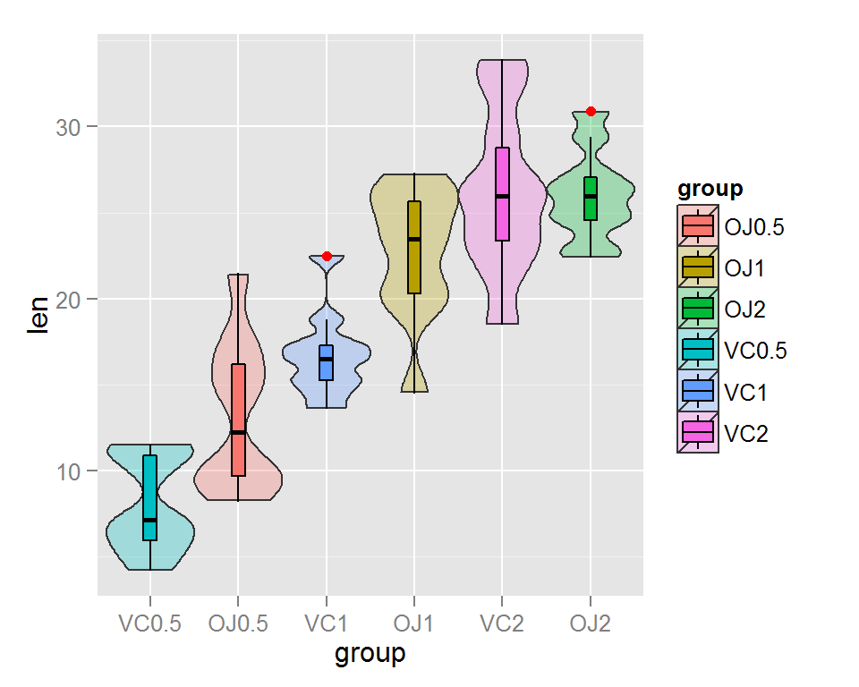

```r
ToothGrowth$group<-paste(ToothGrowth$supp,ToothGrowth$dose,sep="")
ggplot(ToothGrowth,aes(y=len, x=group, fill=group)) +
geom_violin(alpha=0.3, width=1, trim = T,scale = "width", adjust = 0.5) +
geom_boxplot(width=0.2, outlier.colour="red",notch = FALSE,notchwidth = .5,alpha = 1, colour = "black") +
scale_x_discrete(limits=c("VC0.5","OJ0.5","VC1","OJ1","VC2","OJ2"))
```

The plot clearly hows that:

1. There is a clear positive correlation between the dosage and the tooth growth
2. With the smaller dosages (0.5-1mg), Orange juce is more effective than ascorbic-acid, and has better performance. With the higher dosage (2mg), the two delivery methods are about the same (VC is even slightly larger, and has larger max value).
3. With smaller doses (0.5-1mg), the variance of the OJ group was larger than the variance of the VC group, while with the high dose (2mg), this was reversed
4. From the anomaly of the 2mg dose, I tend to suspect that the OJ and VC observation for 2mg where switched (of course there may be other explanations).

```r
ToothGrowth$id<-rep(1:10,6)
tg<-acast(ToothGrowth, group~id, value.var="len")
tgmean<-apply(tg, 1, mean)      #the means of all samples
tgsd<-apply(tg, 1, sd)          #the std-deviations of all
ul<-tgmean+tgsd*1.96/sqrt(10) #upper limit vector
ll<-tgmean-tgsd*1.96/sqrt(10) #lower limit vector
```

**Summary of the data:**

The following table shows a suumary of the 6 groups, including their 95% confidence interval, which was calculated according to CLT using $\overline{X}\pm 1.96*s/\sqrt{10}$:

| Dose (mg) | Supp. | Avg Length | Std deviation | 95% lower limit | 95% upper limit |
| --- | --- | --- | --- | --- | --- |
| 0.5 | VC | 7.98 | 2.7466 | 6.2776 | 9.6824 |
| 0.5 | OJ | 13.23 | 4.4597 | 10.4658 | 15.9942 |
| 1.0 | VC | 16.77 | 2.5153 | 15.211 | 18.329 |
| 1.0 | OJ | 22.7 | 3.911 | 20.276 | 25.124 |
| 2.0 | VC | 26.14 | 4.7977 | 23.1663 | 29.1137 |
| 2.0 | OJ | 26.06 | 2.6551 | 24.4144 | 27.7056 |

**Hypothesis Tests:**

The following sections study the effect of the dose and the delivery method on the length of the teeth, using several variations of two-sample t-tests for len vs. supp and len vs. dose.

**Test Assamptions:** No paired observations, no equal variances accross groups, interval confidence level is 95% and the null hypothesis to be tested is that there the differences between the means of the tested groups are 0.

**Length by Dose Testing**

I have defined two basic tests for len vs dose: One comparing between 0.5mg and 1mg and the other one comparing between 1mg and 2mg. The two basic tests included both delivery methods (OJ and VC). Then, these two tess were repeated for subsets of OJ only and for VC only, to neutralize the effect of the large variance added due to the difference between the two delivery methods.

The six tests were in the format of:

```r
t.test(len ~ dose, data = ToothGrowth, subset= (per-test-subset)
```

```r
td051all<-t.test(len ~ dose, subset= (dose==0.5 | dose == 1),  data = ToothGrowth)

td051oj<-t.test(len ~ dose, subset= ((dose==0.5 | dose == 1)&supp=="OJ"), data = ToothGrowth)

td051vc<-t.test(len ~ dose, subset= ((dose==0.5 | dose == 1)&supp=="VC"), data = ToothGrowth)

td12all<-t.test(len ~ dose, subset= (dose==1 | dose == 2), data = ToothGrowth)

td12oj<-t.test(len ~ dose,subset= ((dose==1 | dose == 2)&supp=="OJ"), data = ToothGrowth)

td12vc<-t.test(len ~ dose, subset= ((dose==1 | dose == 2)&supp=="VC"), data = ToothGrowth)
```

The test results were collected into the following table (using inline r expressions):

| Test/Subset | Statistic | DF | P-value | 95% Conf. Interval | Mean diff. |
| --- | --- | --- | --- | --- | --- |
| 0.5mg vs 1mg, OJ+VC | -6.4766 | 37.9864 | 1.2683 × 10<sup>-7</sup> | -11.9838, -6.2762 | 9.13 |
| 1mg vs 2mg, OJ+VC | -4.9005 | 37.1011 | 1.9064 × 10<sup>-5</sup> | -8.9965, -3.7335 | 6.365 |
| 0.5mg vs 1mg, OJ | -5.0486 | 17.6983 | 8.7849 × 10<sup>-5</sup> | -13.4156, -5.5244 | 9.47 |
| 1mg vs 2mg, OJ | -2.2478 | 15.8424 | 0.0392 | -6.5314, -0.1886 | 3.36 |
| 0.5mg vs 1mg, VC | -7.4634 | 17.8624 | 6.811 × 10<sup>-7</sup> | -11.2657, -6.3143 | 8.79 |
| 1mg vs 2mg, VC | -5.4698 | 13.6 | 9.1556 × 10<sup>-5</sup> | -13.0543, -5.6857 | 9.37 |

**Len by Dose Test Conclusions:**

All the test results are consistent in rejecting the null hypothesis, and concluding that there is a very high probability that an increased dose would result with increased tooth length.

In the case of OJ-1mg vs OJ-2mg, the rejection is quite marginal, with a 3.9% probability, which is quite close to be 5% acceptence limit. All the other cases show extremely low probability that the difference between the means is 0.

**Length by Delivery Method (len by supp) testing**

The basic test for len by supp, included all 6 groups of all three dose groups in each supp group. The problem is hat the large variance contributed by the different doses obscures the distinct difference caused by the supp within some of the dose groups, so I ran the test again for each subset of single dose.

```r
tsall<-t.test(len ~ supp, data = ToothGrowth)

ts05<-t.test(len ~ supp, subset= (dose == 0.5), data = ToothGrowth)

ts1<-t.test(len ~ supp, subset= (dose == 1), data = ToothGrowth)

ts2<-t.test(len ~ supp, subset= (dose == 2), data = ToothGrowth)
```

The four tests were in the format of

```r
t.test(len ~ supp, data = ToothGrowth, subset=(dose==per-test-dose))
```

Where the basic test did not have the subset option at all, and the three others were using subsets of the 3 doses respectively.

The test results were collected into the following table (using inline r expressions):

| Test/Subset | Statistic | DF | P-value | 95% Conf. Interval | Mean diff. |
| --- | --- | --- | --- | --- | --- |
| All doses | 1.9153 | 55.3094 | 0.0606 | -0.171, 7.571 | 3.7 |
| Dose=0.5 | 3.1697 | 14.9688 | 0.0064 | 1.7191, 8.7809 | 5.25 |
| Dose=1 | 4.0328 | 15.3577 | 0.001 | 2.8021, 9.0579 | 5.93 |
| Dose=2 | -0.0461 | 14.0398 | 0.9639 | -3.7981, 3.6381 | -0.08 |

**Len by Supp Test Conclusions:**

Looking at all doses together (first row), I cannot rule out the possibility that the difference between the true means of the OJ and the VC groups is 0, since the probaility for such case is above 6%. For doses 0.5mg and 1mg, there is a very low probability that the difference is 0, which is a clear evidence that the OJ is much more effective than the VC with these two doses. However, for dose of 2mg, there is above 96% probability that there is no difference between the two methods, so the null assumption is accepted for 2mg dose.